# Chapitre 0 — Présentation générale

Économétrie des séries temporelles · M1 MBFA

Bilel Sanhaji — Université Paris 8

# De quoi il s’agit

Les données de séries temporelles posent deux difficultés que l’analyse transversale ignore :

- les variables sont corrélées entre elles **à un instant donné**,
- mais aussi **dans le temps**,
- et leurs moments eux-mêmes peuvent varier.

Nous partons des processus **univariés stationnaires**, puis étendons aux processus **non stationnaires** et **multivariés**.

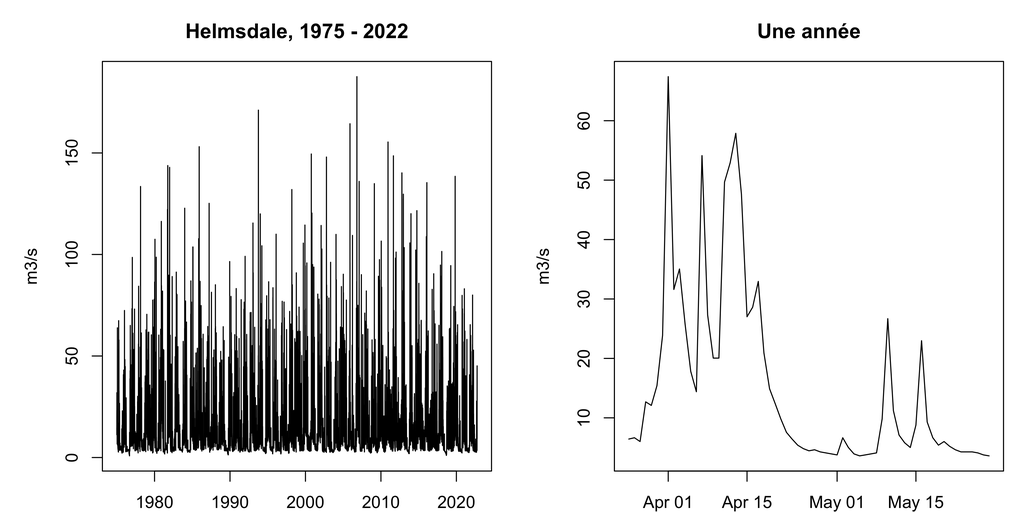

# Plan du cours

|  | Chapitre | Ce que vous saurez faire |
| --- | --- | --- |
| **1** | Introduction et concepts essentiels | Caractériser un processus stochastique, lire une ACF |
| **2** | Processus ARMA stationnaires | Identifier, estimer et valider un ARMA |
| **3** | Racines unitaires | Tester la non-stationnarité, choisir la spécification du test |
| **4** | Séries temporelles multivariées | Estimer un VAR, tester Granger, lire une IRF |
| **5** | Cointégration et correction d’erreur | Reconnaître une relation de long terme, situer un VECM |
| **6** | Ouverture : modèles non linéaires | Situer les modèles à changement de régime |

**11 séances de 3 × 50 min**, environ moitié cours, moitié travaux dirigés et travaux sur machine.

# Objectifs et outils

**À la fin du semestre, vous devez pouvoir :**

- lire un article empirique en macroéconomie ou en finance,
- **reproduire** son analyse,
- la critiquer,
- produire votre propre travail empirique.

**Les travaux sur machine se font en `R` ou en `Python`, au choix.**

Les deux sont pris en charge : chaque fiche de TP a un corrigé dans chaque langage, et une table de correspondance entre les fonctions des deux écosystèmes est fournie.

# Évaluation

| Composante | Poids | Modalité |
| --- | --- | --- |
| **Partiel final sur table** | 60 % | 2 h, sans document |
| **3 TP notés sur machine** | 40 % | Séances 7, 9 et 11 — en séance, individuels |

**Chaque étudiant travaille sur sa propre série** (une station météo différente par étudiant). Vos résultats numériques ne seront ceux de personne d’autre.

Ce qui est noté : la **démarche** et l’**interprétation**, pas la sortie brute. Un résultat gênant correctement discuté vaut mieux qu’un résultat propre non commenté.

**Toutes les communications passent par Moodle et le dépôt GitHub.**